# Bajade_Denisse_Lab4-1

### Scatter plot colored by species

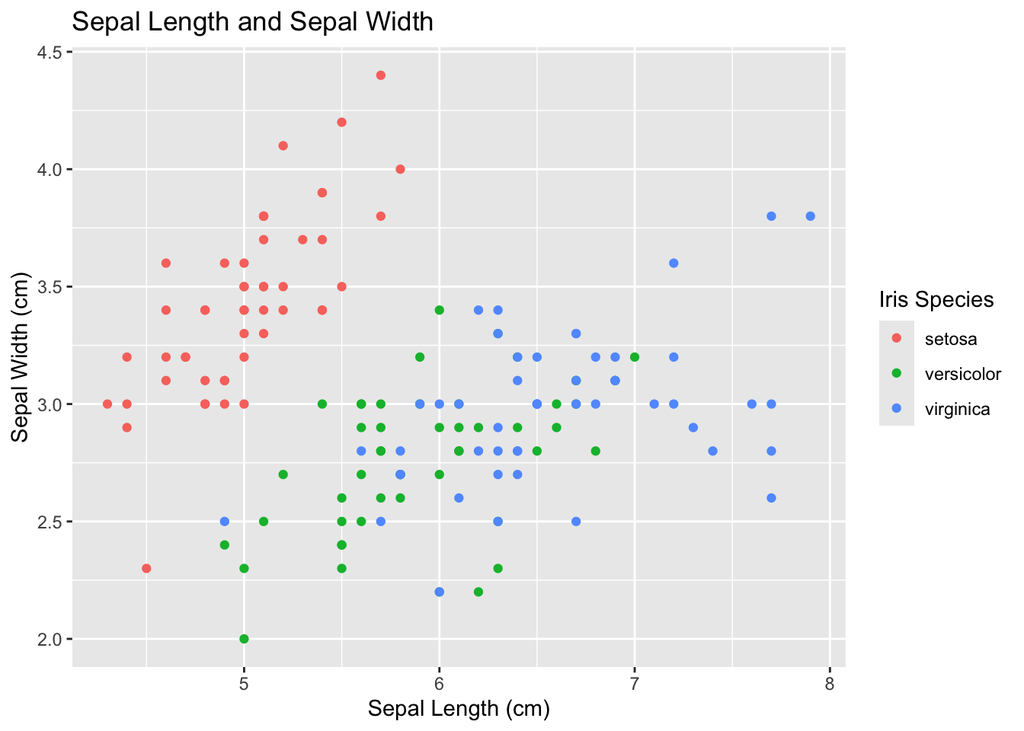

```r
ggplot(
  iris,
  aes(x = Sepal.Length, y = Sepal.Width, color = Species)
) +
  geom_point() +
  labs(
    title = "Sepal Length and Sepal Width",
    x = "Sepal Length (cm)",
    y = "Sepal Width (cm)",
    color = "Iris Species"
  )
```

### 4.5.2 Line plot: `geom_line()`

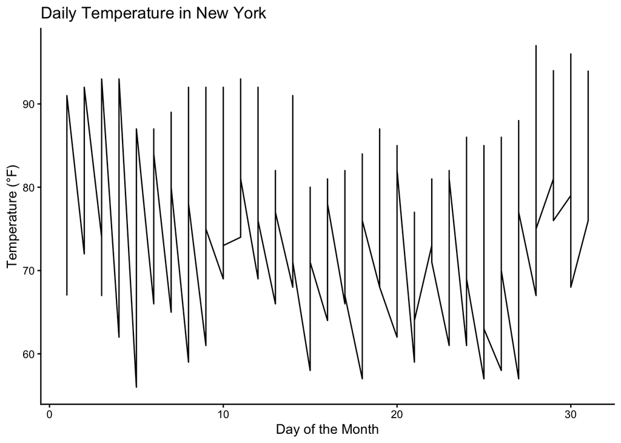

```r
ggplot(
  airquality,
  aes(x = Day, y = Temp)
) +
  geom_line() +
  labs(
    title = "Daily Temperature in New York",
    x = "Day of the Month",
    y = "Temperature (°F)"
  ) +
  theme_classic()
```

### Line plot grouped by month

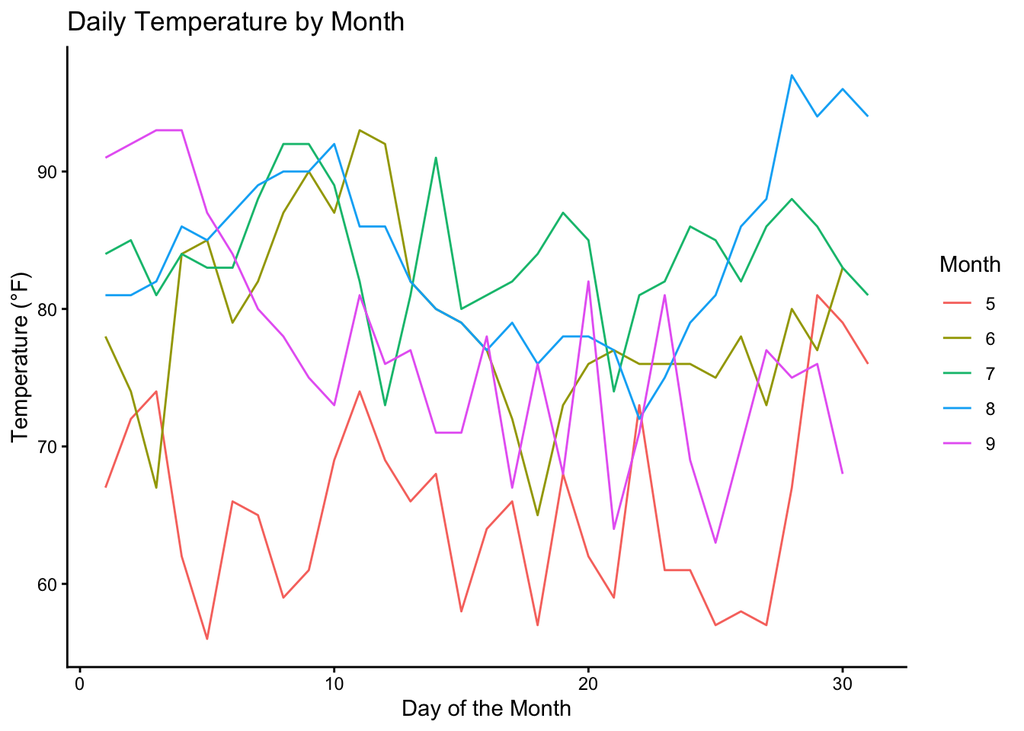

```r
ggplot(
  airquality,
  aes(
    x = Day,
    y = Temp,
    group = factor(Month),
    color = factor(Month)
  )
) +
  geom_line() +
  labs(
    title = "Daily Temperature by Month",
    x = "Day of the Month",
    y = "Temperature (°F)",
    color = "Month"
  ) +
  theme_classic()
```

### 4.5.3 Bar plot: `geom_bar()`

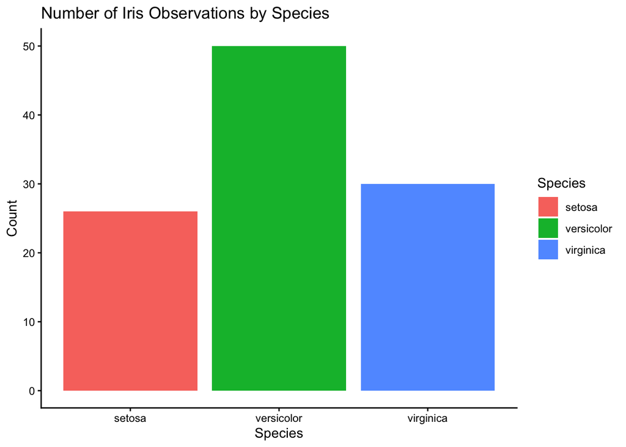

```r
ggplot(
  iris[25:130, ],
  aes(x = Species, fill = Species)
) +
  geom_bar() +
  labs(
    title = "Number of Iris Observations by Species",
    x = "Species",
    y = "Count",
    fill = "Species"
  ) +
  theme_classic()
```

### 4.5.4 Histogram: `geom_histogram()`

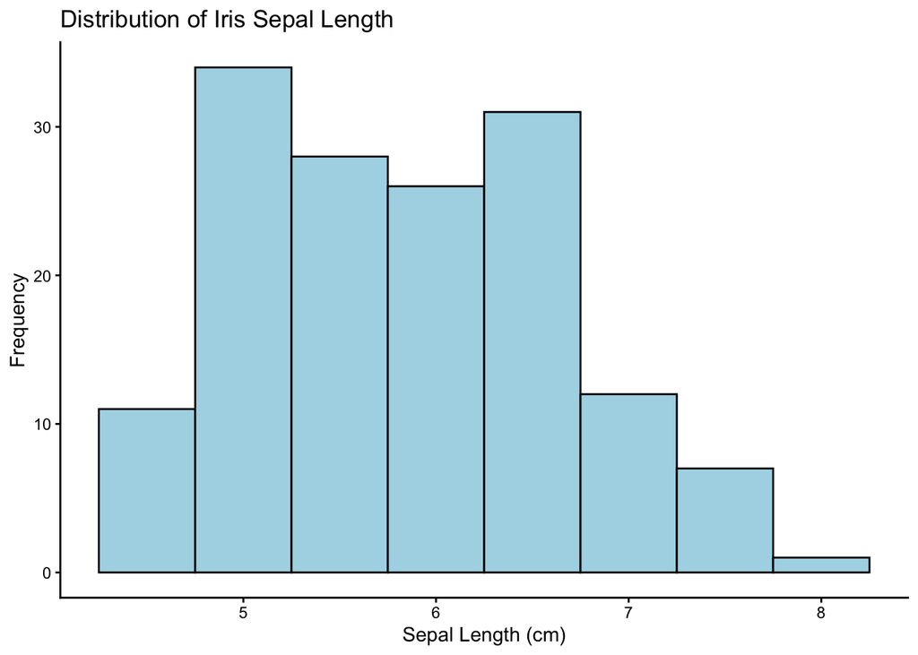

```r
ggplot(iris, aes(x = Sepal.Length)) +
  geom_histogram(
    binwidth = 0.5,
    fill = "lightblue",
    color = "black"
  ) +
  labs(
    title = "Distribution of Iris Sepal Length",
    x = "Sepal Length (cm)",
    y = "Frequency"
  ) +
  theme_classic()
```

### 4.5.5 Box plot: `geom_boxplot()`

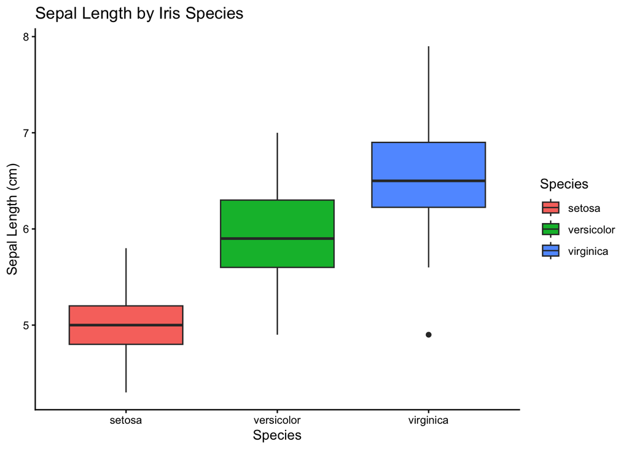

```r
ggplot(
  iris,
  aes(x = Species, y = Sepal.Length, fill = Species)
) +
  geom_boxplot() +
  labs(
    title = "Sepal Length by Iris Species",
    x = "Species",
    y = "Sepal Length (cm)",
    fill = "Species"
  ) +
  theme_classic()
```

### 4.5.6 Bar plot using existing values: `geom_col()`

```r
mean_petal <- aggregate(Petal.Length ~ Species, data = iris, FUN = mean)
mean_petal
```

```
##      Species Petal.Length
## 1     setosa        1.462
## 2 versicolor        4.260
## 3  virginica        5.552
```

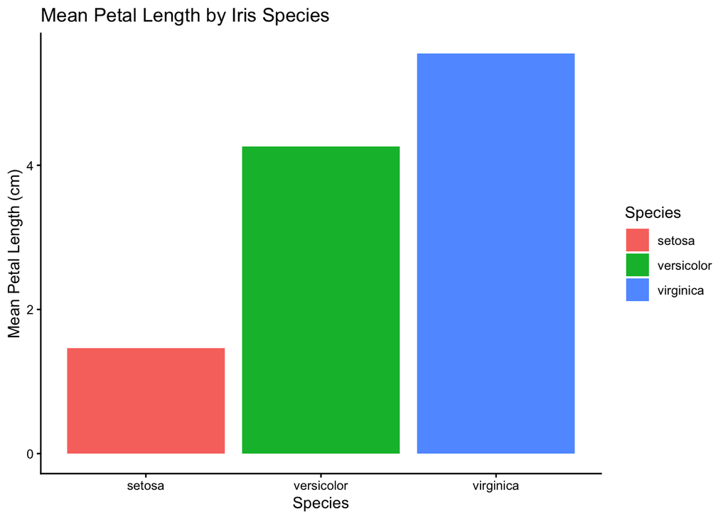

```r
ggplot(
  mean_petal,
  aes(x = Species, y = Petal.Length, fill = Species)
) +
  geom_col() +
  labs(
    title = "Mean Petal Length by Iris Species",
    x = "Species",
    y = "Mean Petal Length (cm)",
    fill = "Species"
  ) +
  theme_classic()
```

### 4.5.7 Adding a trend line: `geom_smooth()`

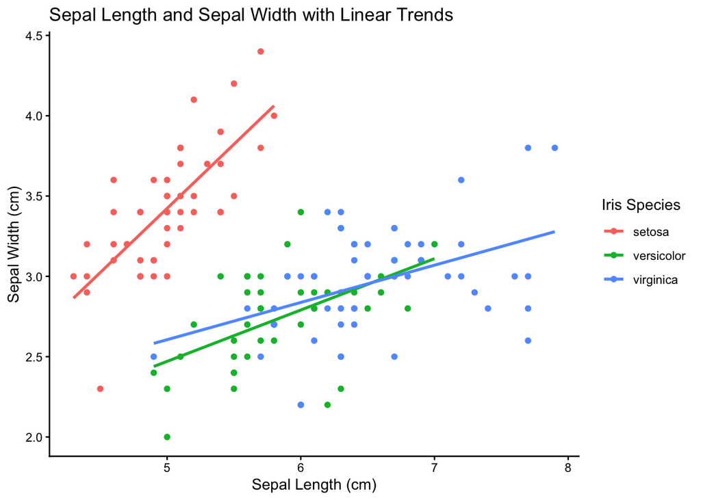

```r
ggplot(
  iris,
  aes(x = Sepal.Length, y = Sepal.Width, color = Species)
) +
  geom_point() +
  geom_smooth(method = "lm", se = FALSE) +
  labs(
    title = "Sepal Length and Sepal Width with Linear Trends",
    x = "Sepal Length (cm)",
    y = "Sepal Width (cm)",
    color = "Iris Species"
  ) +
  theme_classic()
```

### 4.5.8 Heatmaps: `geom_tile()`

```r
temperature_data <- data.frame(
  Site = rep(c("Site A", "Site B", "Site C"), each = 3),
  Month = rep(c("June", "July", "August"), times = 3),
  Temperature = c(27.2, 28.1, 28.5, 26.8, 27.5, 28.0, 29.0, 29.4, 30.1)
)

temperature_data
```

```
##     Site  Month Temperature
## 1 Site A   June        27.2
## 2 Site A   July        28.1
## 3 Site A August        28.5
## 4 Site B   June        26.8
## 5 Site B   July        27.5
## 6 Site B August        28.0
## 7 Site C   June        29.0
## 8 Site C   July        29.4
## 9 Site C August        30.1
```

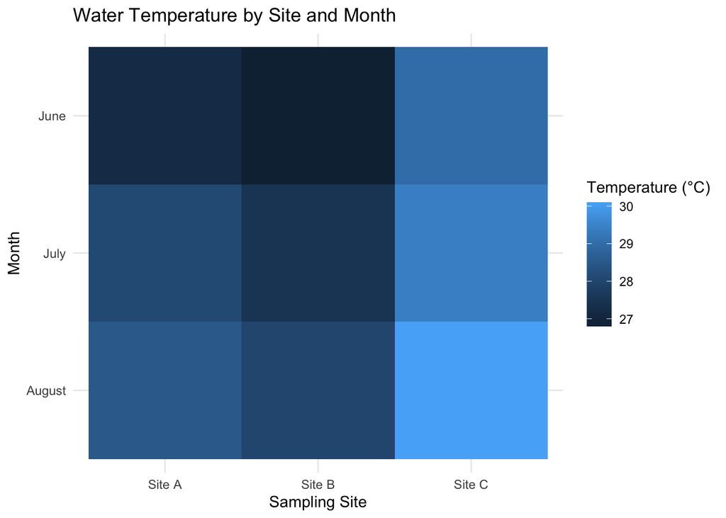

```r
ggplot(
  temperature_data,
  aes(x = Site, y = Month, fill = Temperature)
) +
  geom_tile() +
  labs(
    title = "Water Temperature by Site and Month",
    x = "Sampling Site",
    y = "Month",
    fill = "Temperature (°C)"
  ) +
  theme_minimal()
```

## 4.6 Customizing a Plot

### 4.6.1 Add titles and labels using `labs()`

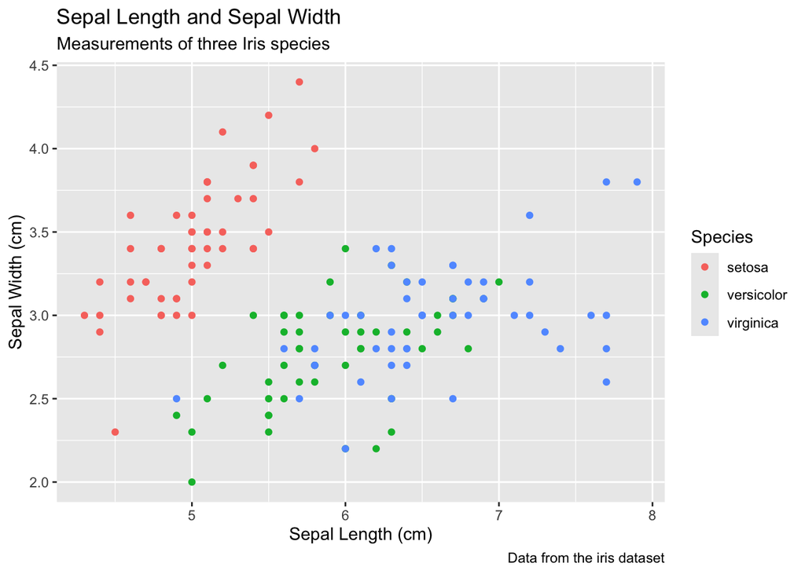

```r
ggplot(
  iris,
  aes(x = Sepal.Length, y = Sepal.Width, color = Species)
) +
  geom_point() +
  labs(
    title = "Sepal Length and Sepal Width",
    subtitle = "Measurements of three Iris species",
    x = "Sepal Length (cm)",
    y = "Sepal Width (cm)",
    caption = "Data from the iris dataset",
    color = "Species"
  )
```

### 4.6.2 Annotating a plot with `annotate()`

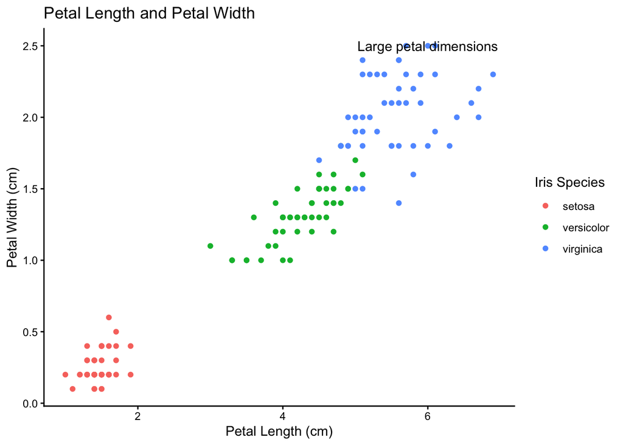

```r
ggplot(
  iris,
  aes(x = Petal.Length, y = Petal.Width, color = Species)
) +
  geom_point() +
  annotate(
    "text",
    x = 6,
    y = 2.5,
    label = "Large petal dimensions"
  ) +
  labs(
    title = "Petal Length and Petal Width",
    x = "Petal Length (cm)",
    y = "Petal Width (cm)",
    color = "Iris Species"
  ) +
  theme_classic()
```

### 4.6.3 Faceting: `facet_wrap()`

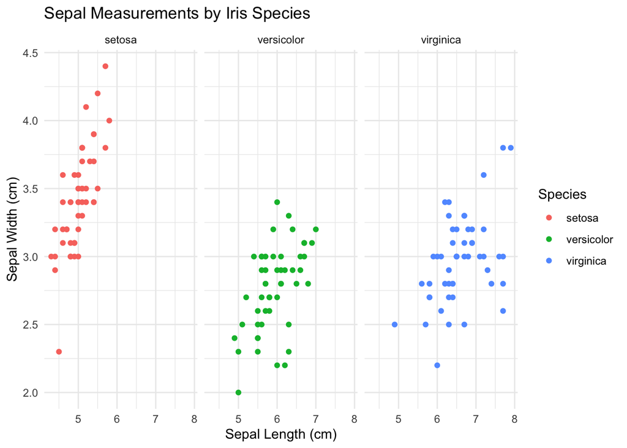

```r
ggplot(
  iris,
  aes(x = Sepal.Length, y = Sepal.Width, color = Species)
) +
  geom_point() +
  facet_wrap(~ Species) +
  labs(
    title = "Sepal Measurements by Iris Species",
    x = "Sepal Length (cm)",
    y = "Sepal Width (cm)"
  ) +
  theme_minimal()
```

### 4.6.4 Applying simple themes

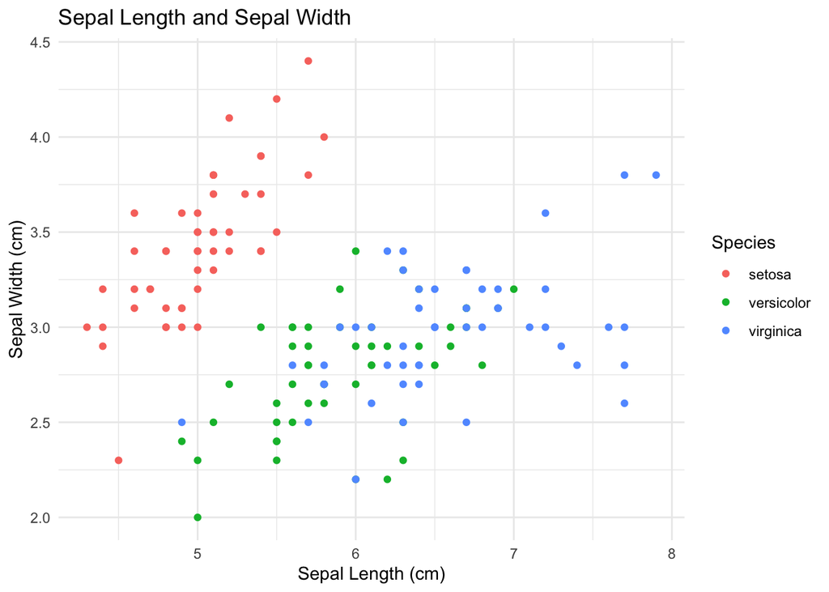

```r
theme_plot <- ggplot(
  iris,
  aes(x = Sepal.Length, y = Sepal.Width, color = Species)
) +
  geom_point() +
  labs(
    title = "Sepal Length and Sepal Width",
    x = "Sepal Length (cm)",
    y = "Sepal Width (cm)",
    color = "Species"
  )

theme_plot + theme_minimal()
```

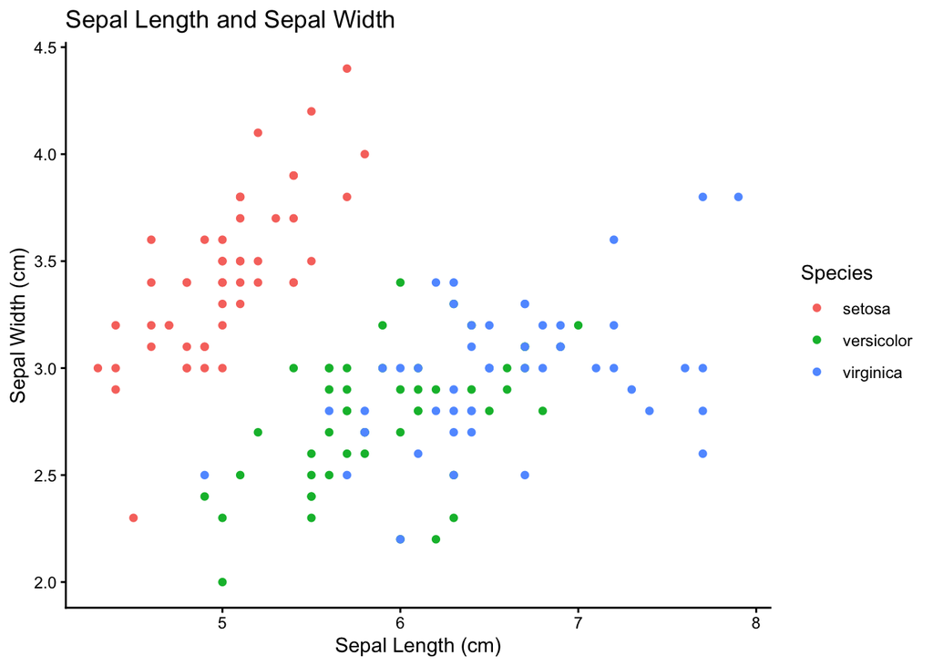

```r
theme_plot + theme_classic()
```

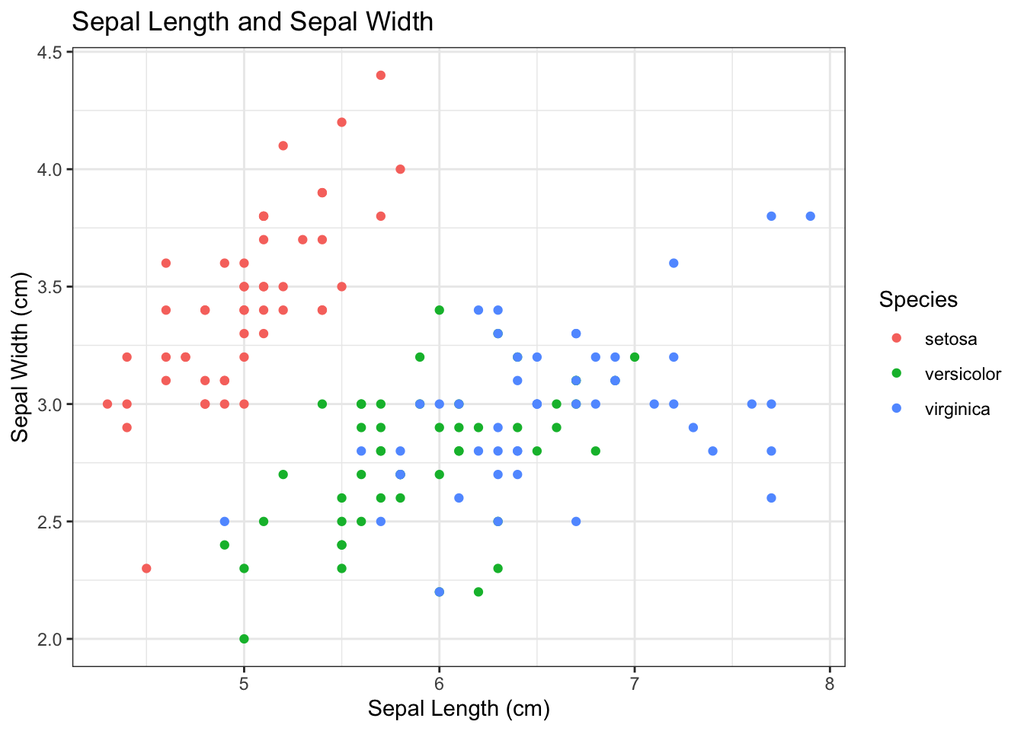

```r
theme_plot + theme_bw()
```

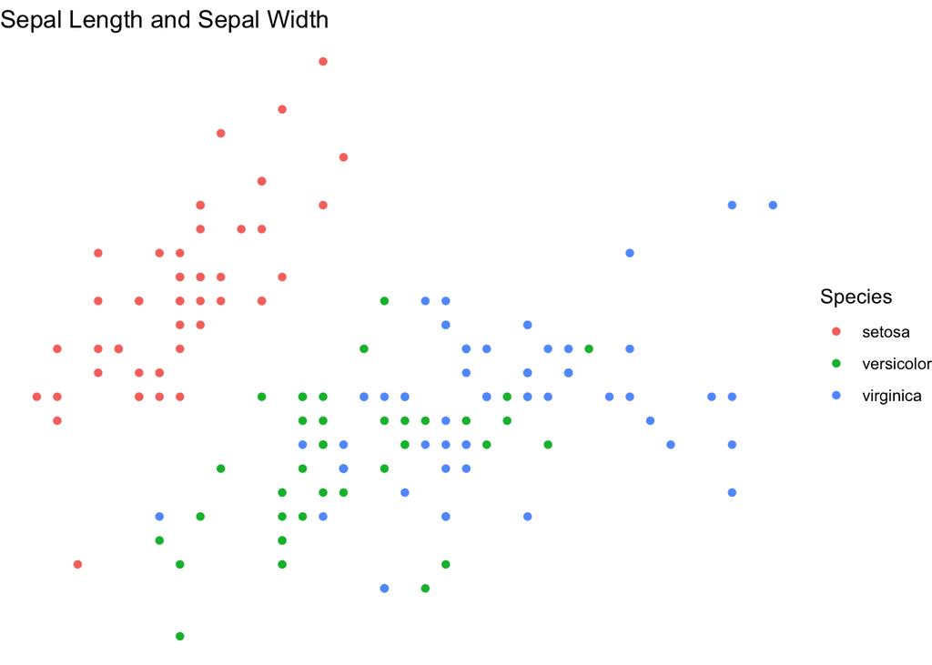

```r
theme_plot + theme_void()
```

### 4.6.5 Combining multiple layers

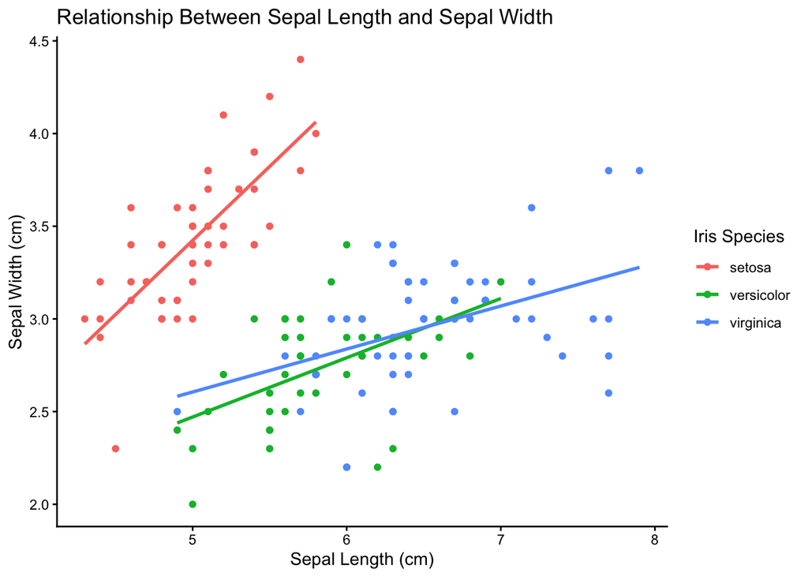

```r
ggplot(
  iris,
  aes(x = Sepal.Length, y = Sepal.Width, color = Species)
) +
  geom_point() +
  geom_smooth(method = "lm", se = FALSE) +
  labs(
    title = "Relationship Between Sepal Length and Sepal Width",
    x = "Sepal Length (cm)",
    y = "Sepal Width (cm)",
    color = "Iris Species"
  ) +
  theme_classic()
```

## 4.7 Saving a Plot: `ggsave()`

The selected plot is saved in Exercise 9 below using `ggsave()` with a JPEG filename and 300 dpi.

## 4.8 Practice Exercises: `airquality`

### Exercise 1. Scatter plot of Wind and Ozone

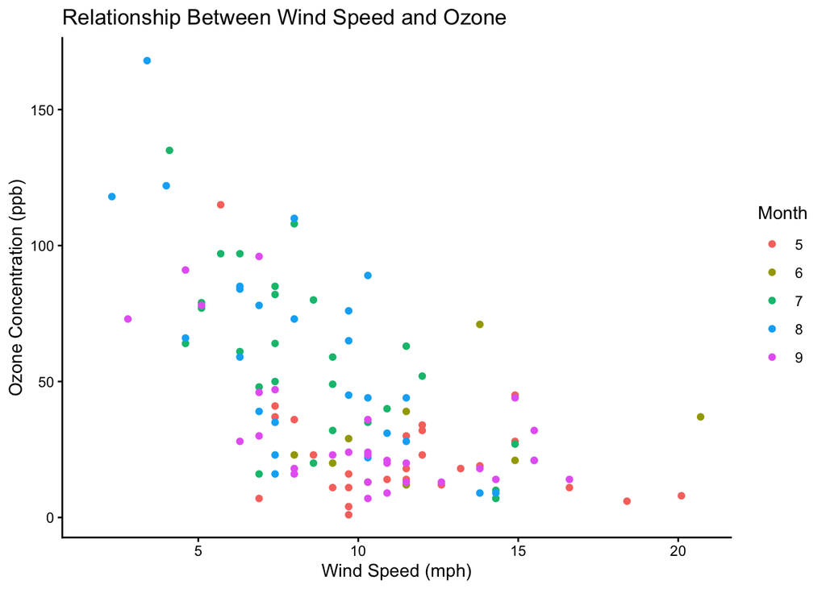

```r
wind_ozone_plot <- ggplot(
  airquality,
  aes(x = Wind, y = Ozone, color = factor(Month))
) +
  geom_point(na.rm = TRUE) +
  labs(
    title = "Relationship Between Wind Speed and Ozone",
    x = "Wind Speed (mph)",
    y = "Ozone Concentration (ppb)",
    color = "Month"
  ) +
  theme_classic()

wind_ozone_plot
```

### Exercise 2. Line plot of Ozone across days

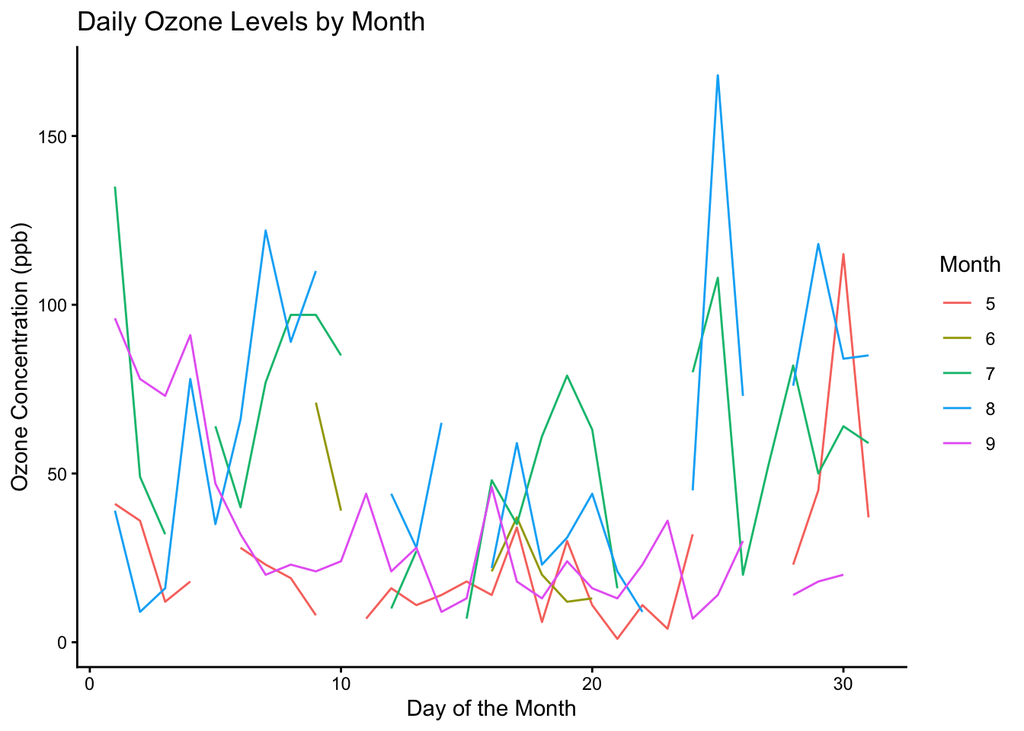

```r
ggplot(
  airquality,
  aes(
    x = Day,
    y = Ozone,
    group = factor(Month),
    color = factor(Month)
  )
) +
  geom_line(na.rm = TRUE) +
  labs(
    title = "Daily Ozone Levels by Month",
    x = "Day of the Month",
    y = "Ozone Concentration (ppb)",
    color = "Month"
  ) +
  theme_classic()
```

### Exercise 3. Histogram of Wind

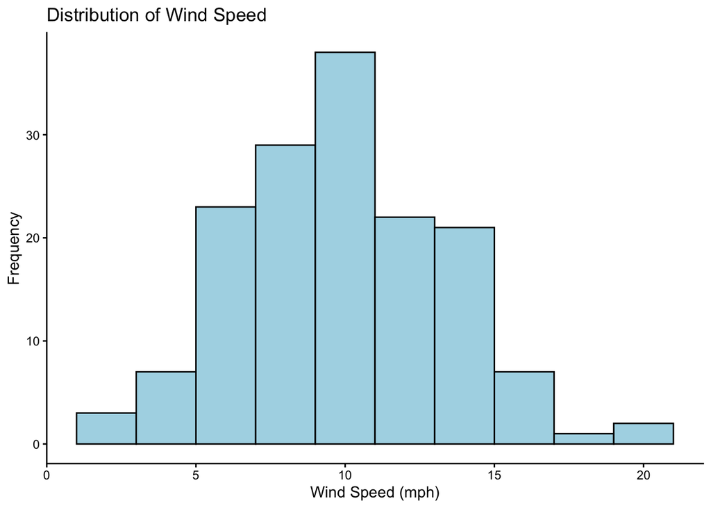

```r
wind_histogram <- ggplot(airquality, aes(x = Wind)) +
  geom_histogram(
    binwidth = 2,
    fill = "lightblue",
    color = "black",
    na.rm = TRUE
  ) +
  labs(
    title = "Distribution of Wind Speed",
    x = "Wind Speed (mph)",
    y = "Frequency"
  ) +
  theme_classic()

wind_histogram
```

**Interpretation:** Most wind-speed observations fall in the middle of the observed range, while fewer observations occur at the lowest and highest speeds. The histogram helps show the distribution and spread of wind speed.

### Exercise 4. Box plot of temperature by month

**Part A**

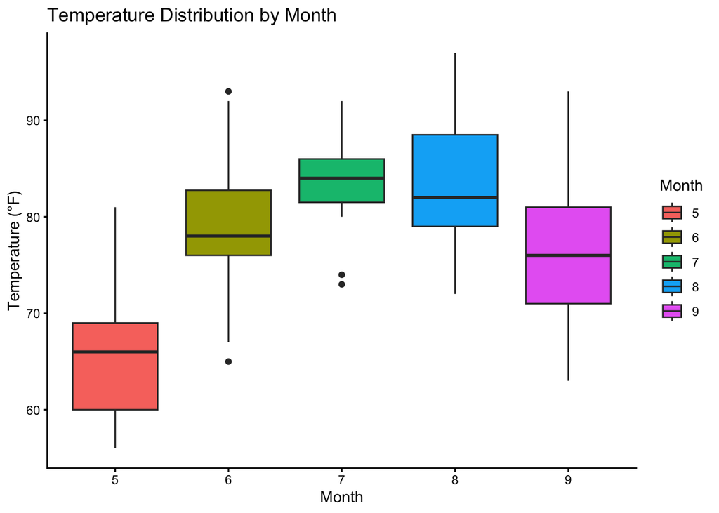

```r
ggplot(
  airquality,
  aes(x = factor(Month), y = Temp, fill = factor(Month))
) +
  geom_boxplot(na.rm = TRUE) +
  labs(
    title = "Temperature Distribution by Month",
    x = "Month",
    y = "Temperature (°F)",
    fill = "Month"
  ) +
  theme_classic()
```

### Exercise 5. Wind and temperature with a linear trend line

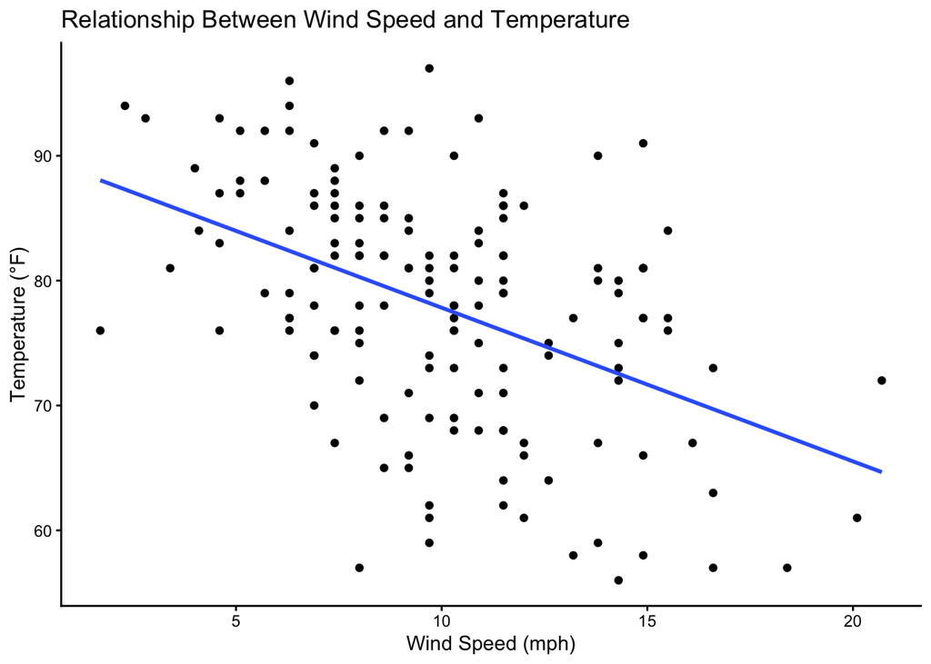

```r
ggplot(airquality, aes(x = Wind, y = Temp)) +
  geom_point(na.rm = TRUE) +
  geom_smooth(method = "lm", se = FALSE, na.rm = TRUE) +
  labs(
    title = "Relationship Between Wind Speed and Temperature",
    x = "Wind Speed (mph)",
    y = "Temperature (°F)"
  ) +
  theme_classic()
```

### Exercise 6. Faceted scatter plot of Wind and Ozone

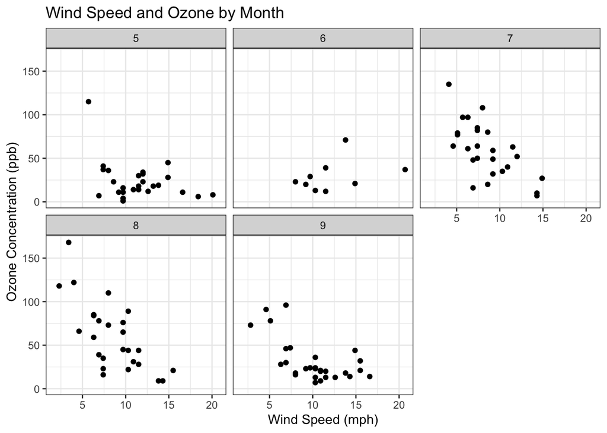

```r
ggplot(airquality, aes(x = Wind, y = Ozone)) +
  geom_point(na.rm = TRUE) +
  facet_wrap(~ Month) +
  labs(
    title = "Wind Speed and Ozone by Month",
    x = "Wind Speed (mph)",
    y = "Ozone Concentration (ppb)"
  ) +
  theme_bw()
```

### Exercise 7. Bar plot of mean temperature by month

```r
mean_temp <- aggregate(
  Temp ~ Month,
  data = airquality,
  FUN = mean,
  na.rm = TRUE
)
mean_temp$Month <- factor(mean_temp$Month)
mean_temp
```

```
##   Month     Temp
## 1     5 65.54839
## 2     6 79.10000
## 3     7 83.90323
## 4     8 83.96774
## 5     9 76.90000
```

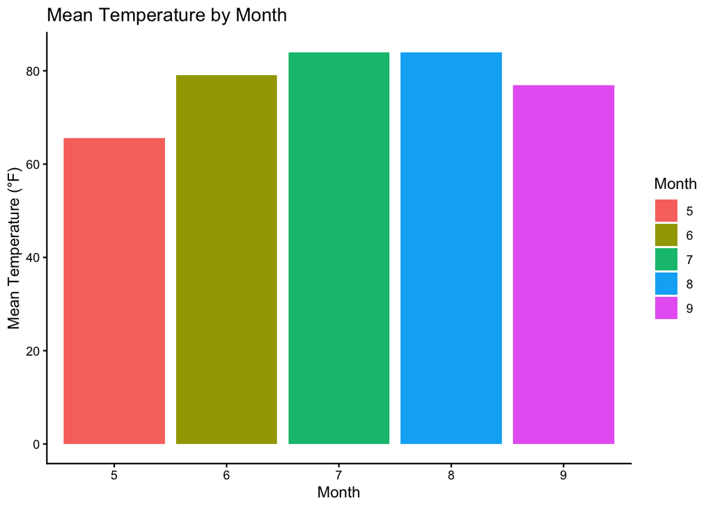

```r
ggplot(
  mean_temp,
  aes(x = Month, y = Temp, fill = Month)
) +
  geom_col() +
  labs(
    title = "Mean Temperature by Month",
    x = "Month",
    y = "Mean Temperature (°F)",
    fill = "Month"
  ) +
  theme_classic()
```

### Exercise 8. Heatmap of temperature by day and month

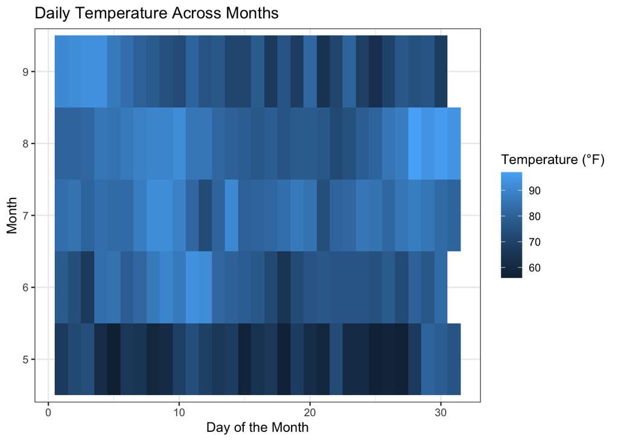

```r
ggplot(
  airquality,
  aes(x = Day, y = factor(Month), fill = Temp)
) +
  geom_tile() +
  labs(
    title = "Daily Temperature Across Months",
    x = "Day of the Month",
    y = "Month",
    fill = "Temperature (°F)"
  ) +
  theme_bw()
```

The following code identifies the observation with the highest recorded temperature:

```r
highest_temp <- airquality[which.max(airquality$Temp), c("Month", "Day", "Temp")]
highest_temp
```

```
##     Month Day Temp
## 120     8  28   97
```

The maximum recorded temperature is **97 °F**. The first observation with this temperature is in **Month 8, Day 28**.

### Exercise 9. Save a plot using `ggsave()`

```r
ggsave(
  filename = "Bajade_Denisse_Plot.jpeg",
  plot = wind_ozone_plot,
  width = 7,
  height = 5,
  units = "in",
  dpi = 300
)
```

# BIO 118 Laboratory Exercise 4B: Exploratory Data Analysis

## 4.1 Loading and Exploring the WHO Dataset

```r
data("who", package = "tidyr")

glimpse(who)
```

```
## Rows: 7,240
## Columns: 60
## $ country      <chr> "Afghanistan", "Afghanistan", "Afghanistan", "Afghanistan…
## $ iso2         <chr> "AF", "AF", "AF", "AF", "AF", "AF", "AF", "AF", "AF", "AF…
## $ iso3         <chr> "AFG", "AFG", "AFG", "AFG", "AFG", "AFG", "AFG", "AFG", "…
## $ year         <dbl> 1980, 1981, 1982, 1983, 1984, 1985, 1986, 1987, 1988, 198…
## $ new_sp_m014  <dbl> NA, NA, NA, NA, NA, NA, NA, NA, NA, NA, NA, NA, NA, NA, N…
## $ new_sp_m1524 <dbl> NA, NA, NA, NA, NA, NA, NA, NA, NA, NA, NA, NA, NA, NA, N…
## $ new_sp_m2534 <dbl> NA, NA, NA, NA, NA, NA, NA, NA, NA, NA, NA, NA, NA, NA, N…
## $ new_sp_m3544 <dbl> NA, NA, NA, NA, NA, NA, NA, NA, NA, NA, NA, NA, NA, NA, N…
## $ new_sp_m4554 <dbl> NA, NA, NA, NA, NA, NA, NA, NA, NA, NA, NA, NA, NA, NA, N…
## $ new_sp_m5564 <dbl> NA, NA, NA, NA, NA, NA, NA, NA, NA, NA, NA, NA, NA, NA, N…
## $ new_sp_m65   <dbl> NA, NA, NA, NA, NA, NA, NA, NA, NA, NA, NA, NA, NA, NA, N…
## $ new_sp_f014  <dbl> NA, NA, NA, NA, NA, NA, NA, NA, NA, NA, NA, NA, NA, NA, N…
## $ new_sp_f1524 <dbl> NA, NA, NA, NA, NA, NA, NA, NA, NA, NA, NA, NA, NA, NA, N…
```

[output cut: 47 more lines]

```r
head(who)
```

```
## # A tibble: 6 × 60
##   country   iso2  iso3   year new_sp_m014 new_sp_m1524 new_sp_m2534 new_sp_m3544
##   <chr>     <chr> <chr> <dbl>       <dbl>        <dbl>        <dbl>        <dbl>
## 1 Afghanis… AF    AFG    1980          NA           NA           NA           NA
## 2 Afghanis… AF    AFG    1981          NA           NA           NA           NA
## 3 Afghanis… AF    AFG    1982          NA           NA           NA           NA
## 4 Afghanis… AF    AFG    1983          NA           NA           NA           NA
## 5 Afghanis… AF    AFG    1984          NA           NA           NA           NA
## 6 Afghanis… AF    AFG    1985          NA           NA           NA           NA
## # ℹ 52 more variables: new_sp_m4554 <dbl>, new_sp_m5564 <dbl>,
## #   new_sp_m65 <dbl>, new_sp_f014 <dbl>, new_sp_f1524 <dbl>,
## #   new_sp_f2534 <dbl>, new_sp_f3544 <dbl>, new_sp_f4554 <dbl>,
## #   new_sp_f5564 <dbl>, new_sp_f65 <dbl>, new_sn_m014 <dbl>,
## #   new_sn_m1524 <dbl>, new_sn_m2534 <dbl>, new_sn_m3544 <dbl>,
## #   new_sn_m4554 <dbl>, new_sn_m5564 <dbl>, new_sn_m65 <dbl>,
## #   new_sn_f014 <dbl>, new_sn_f1524 <dbl>, new_sn_f2534 <dbl>, …
```

```r
dim(who)
```

```
## [1] 7240   60
```

### Guide Questions 1–5

1. **How many observations and variables are in the dataset?**  
   The WHO dataset contains 7,240 observations and 60 variables. Each observation represents a country-year record, while the variables include country identifiers, year, and different TB case categories.
2. **Which variables identify the country and year?**  
   `country`, `iso2`, and `iso3` identify the country. `year` identifies the year of the record.
3. **Which variables contain information about TB cases?**  
   The columns beginning with names such as `new_sp`, `new_sn`, `new_ep`, and `newrel` contain TB case information.
4. **What types of variables are country and year?**  
   `country` is character data, while `year` is numeric.
5. **What do you notice about the structure of the TB case variables?**  
   The TB case information is stored in many separate columns. The column names encode diagnosis category, sex, and age group, so the dataset is initially in a wide format.

## 4.2 Examining Missing Data

```r
missing_by_column <- colSums(is.na(who))
missing_by_column
```

```
##      country         iso2         iso3         year  new_sp_m014 new_sp_m1524
##            0           34            0            0         4067         4031
## new_sp_m2534 new_sp_m3544 new_sp_m4554 new_sp_m5564   new_sp_m65  new_sp_f014
##         4034         4021         4017         4022         4031         4066
## new_sp_f1524 new_sp_f2534 new_sp_f3544 new_sp_f4554 new_sp_f5564   new_sp_f65
##         4046         4040         4041         4036         4045         4043
##  new_sn_m014 new_sn_m1524 new_sn_m2534 new_sn_m3544 new_sn_m4554 new_sn_m5564
##         6195         6210         6218         6215         6213         6219
##   new_sn_m65  new_sn_f014 new_sn_f1524 new_sn_f2534 new_sn_f3544 new_sn_f4554
##         6220         6200         6218         6224         6220         6222
## new_sn_f5564   new_sn_f65  new_ep_m014 new_ep_m1524 new_ep_m2534 new_ep_m3544
##         6223         6221         6202         6214         6220         6216
## new_ep_m4554 new_ep_m5564   new_ep_m65  new_ep_f014 new_ep_f1524 new_ep_f2534
##         6220         6225         6222         6208         6219         6219
## new_ep_f3544 new_ep_f4554 new_ep_f5564   new_ep_f65  newrel_m014 newrel_m1524
##         6219         6223         6223         6226         7050         7058
## newrel_m2534 newrel_m3544 newrel_m4554 newrel_m5564   newrel_m65  newrel_f014
##         7057         7056         7056         7055         7058         7050
## newrel_f1524 newrel_f2534 newrel_f3544 newrel_f4554 newrel_f5564   newrel_f65
##         7056         7058         7057         7057         7057         7055
```

### Guide Questions 6–8

6. **Which variables contain missing values?**  
   The output above identifies the variables with missing values. Several TB case columns contain missing values, and `iso2` also has some missing entries.
7. **Are missing values common or uncommon in the TB case variables?**  
   They are common in many TB case columns. The counts show that many country-year-category combinations do not have a recorded value.
8. **Why might missing observations occur in a large international dataset?**  
   Countries may differ in testing, reporting systems, data collection, and the years for which information is available. Missing data can also result from incomplete records or changes in reporting practices. A missing value does not necessarily mean zero cases.

## 4.3 Tidying the Dataset

### 4.3.1 Convert the dataset to long format

```r
who_tidy <- who %>%
  pivot_longer(
    cols = -c(country, iso2, iso3, year),
    names_to = "profile",
    values_to = "cases"
  )

glimpse(who_tidy)
```

```
## Rows: 405,440
## Columns: 6
## $ country <chr> "Afghanistan", "Afghanistan", "Afghanistan", "Afghanistan", "A…
## $ iso2    <chr> "AF", "AF", "AF", "AF", "AF", "AF", "AF", "AF", "AF", "AF", "A…
## $ iso3    <chr> "AFG", "AFG", "AFG", "AFG", "AFG", "AFG", "AFG", "AFG", "AFG",…
## $ year    <dbl> 1980, 1980, 1980, 1980, 1980, 1980, 1980, 1980, 1980, 1980, 19…
## $ profile <chr> "new_sp_m014", "new_sp_m1524", "new_sp_m2534", "new_sp_m3544",…
## $ cases   <dbl> NA, NA, NA, NA, NA, NA, NA, NA, NA, NA, NA, NA, NA, NA, NA, NA…
```

```r
head(who_tidy)
```

```
## # A tibble: 6 × 6
##   country     iso2  iso3   year profile      cases
##   <chr>       <chr> <chr> <dbl> <chr>        <dbl>
## 1 Afghanistan AF    AFG    1980 new_sp_m014     NA
## 2 Afghanistan AF    AFG    1980 new_sp_m1524    NA
## 3 Afghanistan AF    AFG    1980 new_sp_m2534    NA
## 4 Afghanistan AF    AFG    1980 new_sp_m3544    NA
## 5 Afghanistan AF    AFG    1980 new_sp_m4554    NA
## 6 Afghanistan AF    AFG    1980 new_sp_m5564    NA
```

### 4.3.2 Separate information contained in `profile`

```r
who_tidy <- who_tidy %>%
  mutate(
    profile = gsub("newrel_", "new_rel_", profile)
  ) %>%
  separate(
    profile,
    into = c("new", "type", "sex_age"),
    sep = "_",
    fill = "right",
    extra = "merge"
  ) %>%
  separate(
    sex_age,
    into = c("sex", "age"),
    sep = "(?<=m|f)",
    fill = "right",
    extra = "merge"
  )

glimpse(who_tidy)
```

```
## Rows: 405,440
## Columns: 9
## $ country <chr> "Afghanistan", "Afghanistan", "Afghanistan", "Afghanistan", "A…
## $ iso2    <chr> "AF", "AF", "AF", "AF", "AF", "AF", "AF", "AF", "AF", "AF", "A…
## $ iso3    <chr> "AFG", "AFG", "AFG", "AFG", "AFG", "AFG", "AFG", "AFG", "AFG",…
## $ year    <dbl> 1980, 1980, 1980, 1980, 1980, 1980, 1980, 1980, 1980, 1980, 19…
## $ new     <chr> "new", "new", "new", "new", "new", "new", "new", "new", "new",…
## $ type    <chr> "sp", "sp", "sp", "sp", "sp", "sp", "sp", "sp", "sp", "sp", "s…
## $ sex     <chr> "m", "m", "m", "m", "m", "m", "m", "f", "f", "f", "f", "f", "f…
## $ age     <chr> "014", "1524", "2534", "3544", "4554", "5564", "65", "014", "1…
## $ cases   <dbl> NA, NA, NA, NA, NA, NA, NA, NA, NA, NA, NA, NA, NA, NA, NA, NA…
```

```r
head(who_tidy)
```

```
## # A tibble: 6 × 9
##   country     iso2  iso3   year new   type  sex   age   cases
##   <chr>       <chr> <chr> <dbl> <chr> <chr> <chr> <chr> <dbl>
## 1 Afghanistan AF    AFG    1980 new   sp    m     014      NA
## 2 Afghanistan AF    AFG    1980 new   sp    m     1524     NA
## 3 Afghanistan AF    AFG    1980 new   sp    m     2534     NA
## 4 Afghanistan AF    AFG    1980 new   sp    m     3544     NA
## 5 Afghanistan AF    AFG    1980 new   sp    m     4554     NA
## 6 Afghanistan AF    AFG    1980 new   sp    m     5564     NA
```

## 4.4 Defining the Data for Analysis

```r
tb_data <- who_tidy %>%
  filter(
    type == "sp",
    !is.na(cases)
  )

glimpse(tb_data)
```

```
## Rows: 44,820
## Columns: 9
## $ country <chr> "Afghanistan", "Afghanistan", "Afghanistan", "Afghanistan", "A…
## $ iso2    <chr> "AF", "AF", "AF", "AF", "AF", "AF", "AF", "AF", "AF", "AF", "A…
## $ iso3    <chr> "AFG", "AFG", "AFG", "AFG", "AFG", "AFG", "AFG", "AFG", "AFG",…
## $ year    <dbl> 1997, 1997, 1997, 1997, 1997, 1997, 1997, 1997, 1997, 1997, 19…
## $ new     <chr> "new", "new", "new", "new", "new", "new", "new", "new", "new",…
## $ type    <chr> "sp", "sp", "sp", "sp", "sp", "sp", "sp", "sp", "sp", "sp", "s…
## $ sex     <chr> "m", "m", "m", "m", "m", "m", "m", "f", "f", "f", "f", "f", "f…
## $ age     <chr> "014", "1524", "2534", "3544", "4554", "5564", "65", "014", "1…
## $ cases   <dbl> 0, 10, 6, 3, 5, 2, 0, 5, 38, 36, 14, 8, 0, 1, 30, 129, 128, 90…
```

### Guide Question 9

9. **What does `type == "sp"` represent in the dataset?**  
   It selects the smear-positive pulmonary TB category. In this exercise, it is used to focus on recorded new smear-positive pulmonary TB cases.

## 4.5 Exploring Variation and Distributions

### 4.5.1 TB cases across years

```r
tb_by_year <- tb_data %>%
  group_by(year) %>%
  summarise(
    total_cases = sum(cases, na.rm = TRUE),
    .groups = "drop"
  )

tb_by_year
```

```
## # A tibble: 33 × 2
##     year total_cases
##    <dbl>       <dbl>
##  1  1980         959
##  2  1981         805
##  3  1982         824
##  4  1983         786
##  5  1984         814
##  6  1985         799
##  7  1986         754
##  8  1987         670
##  9  1988         682
## 10  1989         654
## # ℹ 23 more rows
```

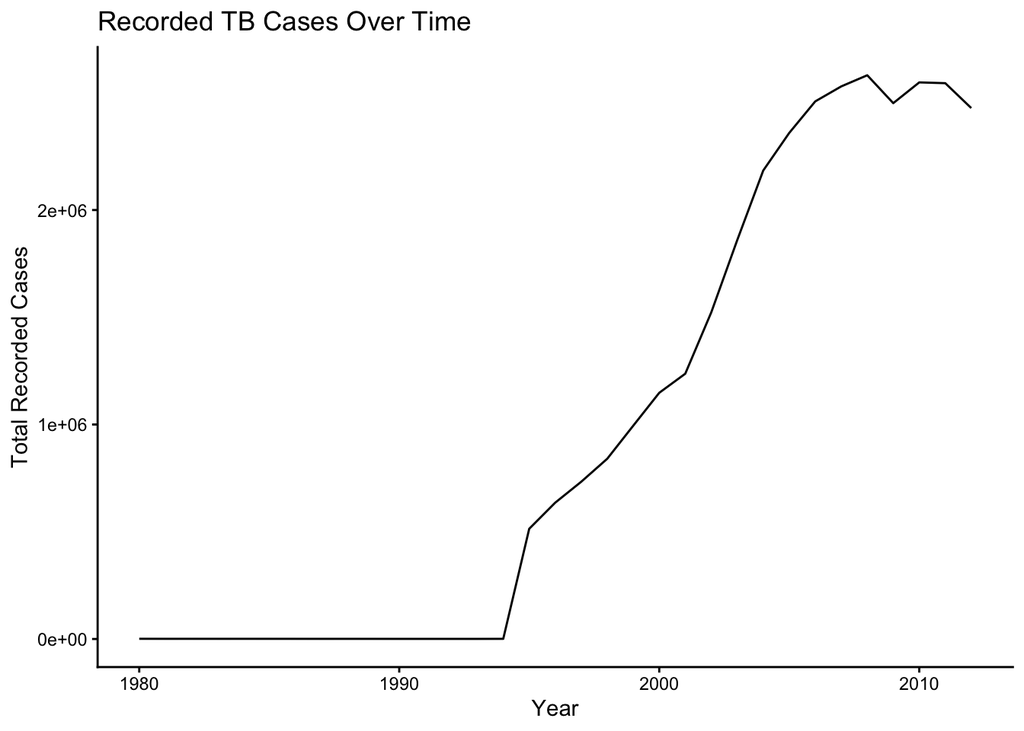

```r
ggplot(tb_by_year, aes(x = year, y = total_cases)) +
  geom_line() +
  labs(
    title = "Recorded TB Cases Over Time",
    x = "Year",
    y = "Total Recorded Cases"
  ) +
  theme_classic()
```

10. **What general pattern do you observe over time?**  
    The total recorded TB cases vary over time. The recorded totals are generally higher in later years than in many earlier years. However, this pattern may reflect changes in reporting coverage as well as changes in the number of cases.
11. **Are there periods when the number of recorded cases changes substantially?**  
    Yes. The line plot shows periods of noticeable increases and decreases in recorded cases. The exact years can be identified by examining the plot and the tb_by_year table.
12. **What are some possible explanations for changes in recorded cases?**  
    Changes may be related to disease occurrence, population size, access to healthcare, testing, and reporting practices. The visualization alone cannot determine which factor caused the changes.

### 4.5.2 Comparing categories: cases by sex

```r
tb_by_sex <- tb_data %>%
  group_by(sex) %>%
  summarise(
    total_cases = sum(cases, na.rm = TRUE),
    .groups = "drop"
  )

tb_by_sex
```

```
## # A tibble: 2 × 2
##   sex   total_cases
##   <chr>       <dbl>
## 1 f        11324409
## 2 m        20586831
```

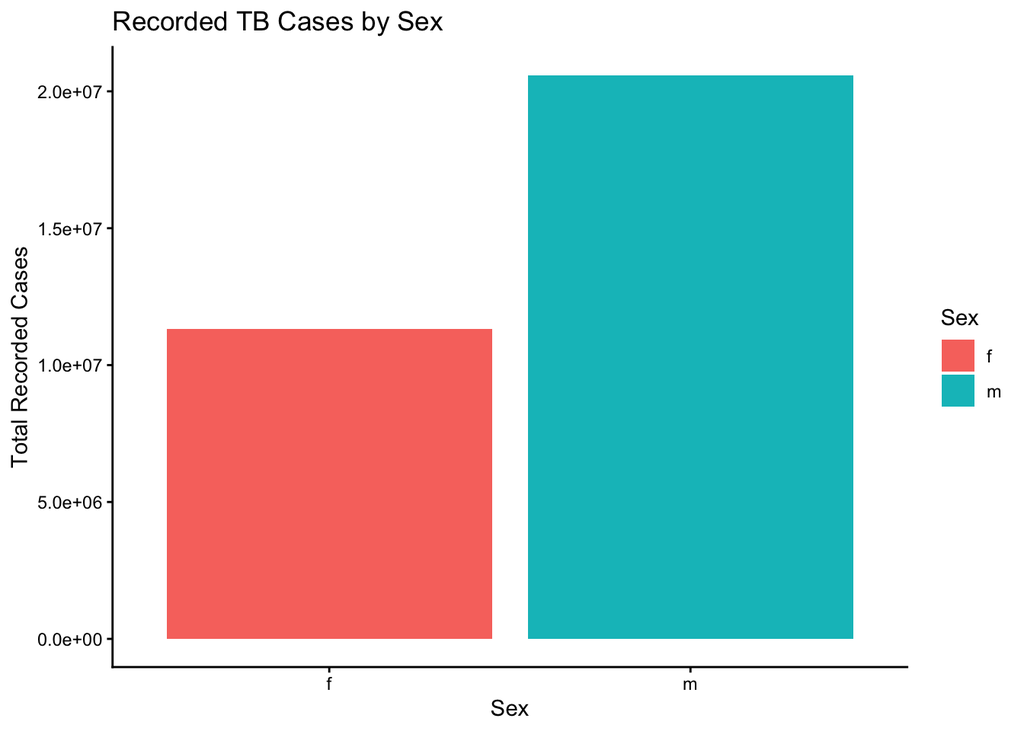

```r
ggplot(tb_by_sex, aes(x = sex, y = total_cases, fill = sex)) +
  geom_col() +
  labs(
    title = "Recorded TB Cases by Sex",
    x = "Sex",
    y = "Total Recorded Cases",
    fill = "Sex"
  ) +
  theme_classic()
```

13. **Which sex has the greater number of recorded cases in this dataset?**  
    Males have the greater total number of recorded cases in this dataset.
14. **What does this comparison tell you?**  
    It shows that the sum of recorded cases for males is higher than the sum for females in the selected data.
15. **What does it not tell you about the risk of TB between males and females?**  
    It does not establish that an individual male has a higher risk of TB. Risk comparisons would require appropriate population denominators and consideration of other factors, such as age, exposure, testing, and reporting.

### 4.5.3 Variation across age groups

```r
tb_by_age <- tb_data %>%
  group_by(age) %>%
  summarise(
    total_cases = sum(cases, na.rm = TRUE),
    .groups = "drop"
  )

tb_by_age
```

```
## # A tibble: 7 × 2
##   age   total_cases
##   <chr>       <dbl>
## 1 014        628491
## 2 1524      5897854
## 3 2534      7435960
## 4 3544      6284568
## 5 4554      4986011
## 6 5564      3579457
## 7 65        3098899
```

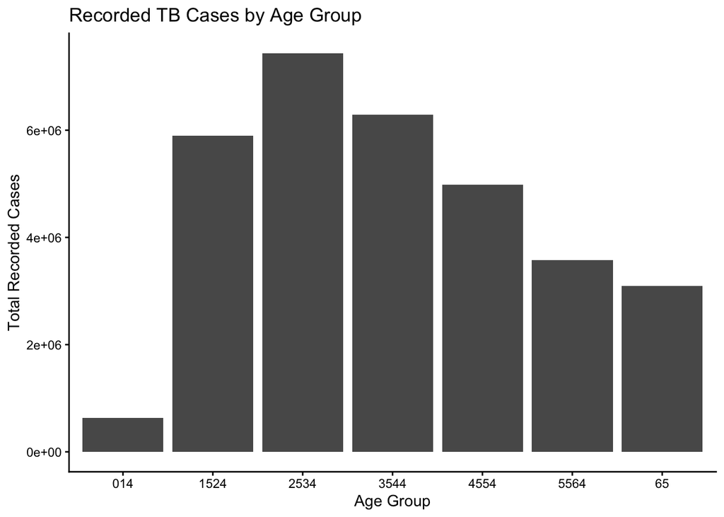

```r
ggplot(tb_by_age, aes(x = age, y = total_cases)) +
  geom_col() +
  labs(
    title = "Recorded TB Cases by Age Group",
    x = "Age Group",
    y = "Total Recorded Cases"
  ) +
  theme_classic()
```

16. **Which age group has the largest number of recorded cases?**  
    The 25–34 age group has the largest total number of recorded cases in the supplied results.
17. **Which age group has the smallest number?**  
    The 0–14 age group has the smallest total number of recorded cases in the supplied results.
18. **What pattern do you observe across age groups?**  
    Recorded cases are highest among adults aged 25–34, followed by those aged 35–44. The totals generally become lower in the older age groups, while the 0–14 age group has the lowest total. These are recorded case counts and do not directly represent the risk of TB in each age group.

## 4.6 Bivariate Analysis: Cases by Year and Sex

```r
tb_year_sex <- tb_data %>%
  group_by(year, sex) %>%
  summarise(
    total_cases = sum(cases, na.rm = TRUE),
    .groups = "drop"
  )

glimpse(tb_year_sex)
```

```
## Rows: 66
## Columns: 3
## $ year        <dbl> 1980, 1980, 1981, 1981, 1982, 1982, 1983, 1983, 1984, 1984…
## $ sex         <chr> "f", "m", "f", "m", "f", "m", "f", "m", "f", "m", "f", "m"…
## $ total_cases <dbl> 337, 622, 291, 514, 293, 531, 295, 491, 311, 503, 286, 513…
```

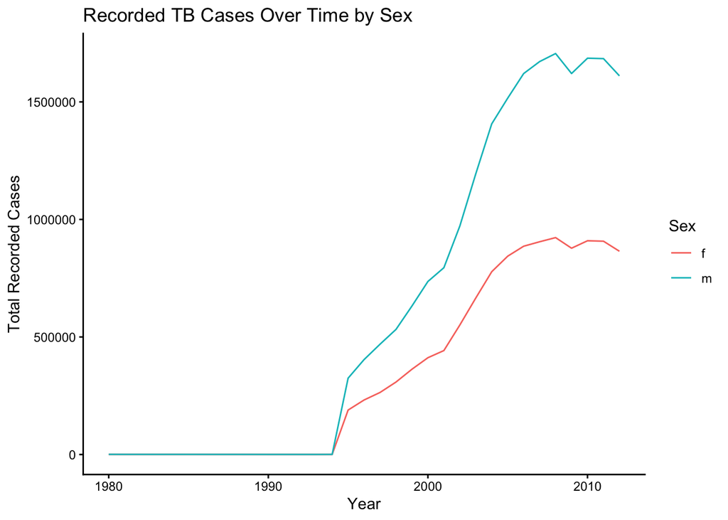

```r
ggplot(
  tb_year_sex,
  aes(x = year, y = total_cases, color = sex)
) +
  geom_line() +
  labs(
    title = "Recorded TB Cases Over Time by Sex",
    x = "Year",
    y = "Total Recorded Cases",
    color = "Sex"
  ) +
  theme_classic()
```

19. **How do the patterns for males and females change over time?**  
    Both groups vary over time, while the male totals are generally higher than the female totals.
20. **Do the two groups show similar or different trends?**  
    They share some broad changes over time, but the total recorded cases differ between the groups. Compare the lines to describe any years when their directions differ.
21. **Are there periods where the difference between the groups appears larger?**  
    The difference appears larger in years when the distance between the two lines is greatest. The plot helps identify those periods, but it does not explain why the difference occurs.

## 4.7 Multivariable Exploration: Year, Age, and Sex

```r
tb_year_age_sex <- tb_data %>%
  group_by(year, age, sex) %>%
  summarise(
    total_cases = sum(cases, na.rm = TRUE),
    .groups = "drop"
  )

glimpse(tb_year_age_sex)
```

```
## Rows: 462
## Columns: 4
## $ year        <dbl> 1980, 1980, 1980, 1980, 1980, 1980, 1980, 1980, 1980, 1980…
## $ age         <chr> "014", "014", "1524", "1524", "2534", "2534", "3544", "354…
## $ sex         <chr> "f", "m", "f", "m", "f", "m", "f", "m", "f", "m", "f", "m"…
## $ total_cases <dbl> 18, 12, 65, 56, 51, 75, 34, 84, 32, 101, 33, 108, 104, 186…
```

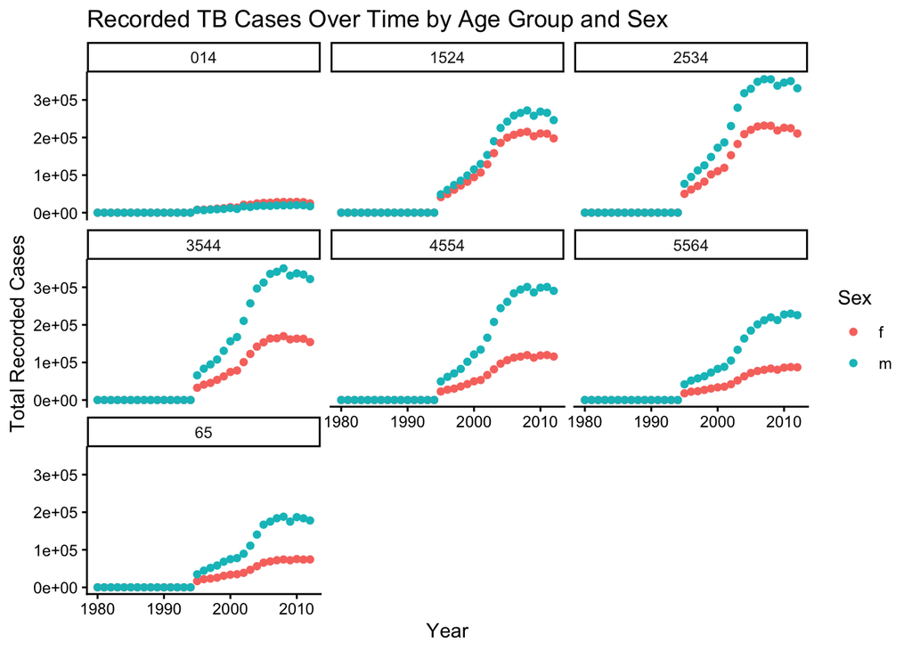

```r
ggplot(
  tb_year_age_sex,
  aes(x = year, y = total_cases, color = sex)
) +
  geom_point() +
  facet_wrap(~ age) +
  labs(
    title = "Recorded TB Cases Over Time by Age Group and Sex",
    x = "Year",
    y = "Total Recorded Cases",
    color = "Sex"
  ) +
  theme_classic()
```

22. **Do the patterns across age groups appear similar?**  
    No. The panels differ in the size and spread of recorded case totals across age groups.
23. **Which age groups show the largest number of recorded cases?**  
    In the supplied example results, the 25–34 and 35–44 age groups have high recorded totals. Check the faceted plot and `tb_by_age` table for the results from your run.
24. **How does the pattern differ between males and females?**  
    Male totals are generally higher than female totals across many age groups, although the size of the difference can vary.
25. **Are there age groups where the two sexes appear more similar or different?**  
    Compare the distance between the male and female points within each panel. Smaller distances indicate more similar recorded totals, while larger distances indicate a greater difference. The plot shows the difference but does not identify its cause.